# Fatality Analysis Reporting System (FARS-2018)

### of the National Highway Traffic Safety Administration of the U.S. Department of Transportation

### TASK

The CEO of GCRoc would like to try to improve their pricing and product offerings for automobile insurance. They have traditionally only operated in the North East but would like to go nationwide. She gives you data on fatal automobile accidents from 2011 and asks you to “see what the data tell you.” GCRoc is still seeking approval for their expansion from the regulators and may only be allowed to add one additional Census region at a time.

### Formulating a question in efforts to gear EDA

#### About the dataset

The FARS (2015-2018) dataset contains data of all motor vehicle accidents (MVAs) that resulted in at least 1 fatality. For every fatality, data about the persons, vehicles and other relevant factors were included. The state of the data is not optimal as there are many missing fields. As insurance revenue is generated primarily from insuring drivers and not paying out claims, it is important to note that this dataset does not include MVAs that did not result in a fatality and therefor provides no ratio of how many total accidents each region/state has per driver.

### Question

The main goal of this analysis is to **identify geographic patterns of risk factors/identifiers of fatalities**. As no information can be inferred about a possible insurance payout per driver, the analysis must be geared towards identifying factors relevant to death/fatalities for which a higher possible insurance payout per driver is possible. In other words, as there is no way of telling how many claims a region might have, this analysis attempts to identify possible fatality claims (claims that result in a higher possible insurance payout due to death) and to identify any geographical patterns in their identifiers (such as medical response time, alcohol levels, urban-rural ratio of fatal MVAs, speed limits, age, person type, air bag (mis)use etc.).

This analysis therefor may only pertain to evaluating how costly a fatality is for the insurance company (more precisely: **does it vary regionally?)** and all recommendations included here should be taken into consideration with the total number of MVAs to determine what region is the most profitable to expand into, should that data become available.

```python
import numpy as np
import pandas as pd
import matplotlib.pyplot as plt
import seaborn as sb
pd.set_option('display.max_columns', None)
```

# Data Cleaning and Wrangling

```python
a18 = pd.read_csv('./FARS2018NationalCSV/ACCIDENT.csv',encoding= 'unicode_escape')
a17 = pd.read_csv('./FARS2017NationalCSV/ACCIDENT.csv',encoding= 'unicode_escape')
a16 = pd.read_csv('./FARS2016NationalCSV/ACCIDENT.csv',encoding= 'unicode_escape')
a15 = pd.read_csv('./FARS2015NationalCSV/ACCIDENT.csv',encoding= 'unicode_escape')
```

```python
p18 = pd.read_csv('./FARS2018NationalCSV/PERSON.csv',encoding= 'unicode_escape')
p17 = pd.read_csv('./FARS2017NationalCSV/PERSON.csv',encoding= 'unicode_escape')
p16 = pd.read_csv('./FARS2016NationalCSV/PERSON.csv',encoding= 'unicode_escape')
p15 = pd.read_csv('./FARS2015NationalCSV/PERSON.csv',encoding= 'unicode_escape')
```

### selecting relevant columns to keep

```python
person_data_columns_to_keep = ['ST_CASE','AGE','SEX','PER_TYP','INJ_SEV','REST_USE','REST_MIS','AIR_BAG','DOA','DRUGS']
```

```python
accident_data_columns_to_keep = ['ST_CASE','STATE','PEDS','PERSONS','RUR_URB','LATITUDE','LONGITUD','FATALS','NOT_HOUR','NOT_MIN','HOSP_HR','HOSP_MN']
```

```python
a18 = a18[accident_data_columns_to_keep]
a17 = a17[accident_data_columns_to_keep]
a16 = a16[accident_data_columns_to_keep]
a15 = a15[accident_data_columns_to_keep]

p18 = p18[person_data_columns_to_keep]
p17 = p17[person_data_columns_to_keep]
p16 = p16[person_data_columns_to_keep]
p15 = p15[person_data_columns_to_keep]
```

### Merging the datasets

```python
t18 = a18.set_index('ST_CASE').join(p18.set_index('ST_CASE'))
t17 = a17.set_index('ST_CASE').join(p17.set_index('ST_CASE'))
t16 = a16.set_index('ST_CASE').join(p16.set_index('ST_CASE'))
t15 = a15.set_index('ST_CASE').join(p15.set_index('ST_CASE'))

# RESETING THE INDEX AS IS NO LONGER VALID PRIMARY KEY (UNIQUENESS VIOLATED BY OUTER JOIN)

t = pd.concat([t18.reset_index(),t17.reset_index(),t16.reset_index(),t15.reset_index()],axis=0)
```

```python
t.head(3)
```

|  | ST_CASE | STATE | PEDS | PERSONS | RUR_URB | LATITUDE | LONGITUD | FATALS | NOT_HOUR | NOT_MIN | HOSP_HR | HOSP_MN | AGE | SEX | PER_TYP | INJ_SEV | REST_USE | REST_MIS | AIR_BAG | DOA | DRUGS |
| --- | --- | --- | --- | --- | --- | --- | --- | --- | --- | --- | --- | --- | --- | --- | --- | --- | --- | --- | --- | --- | --- |
| 0 | 10001 | 1 | 0 | 1 | 1 | 33.591331 | -86.1319 | 1 | 6 | 99 | 88 | 88 | 55 | 1 | 1 | 4 | 20 | 0 | 20 | 7 | 0 |
| 1 | 10002 | 1 | 0 | 2 | 2 | 33.809186 | -87.2898 | 2 | 0 | 99 | 88 | 88 | 24 | 1 | 1 | 4 | 20 | 0 | 1 | 7 | 9 |
| 2 | 10002 | 1 | 0 | 2 | 2 | 33.809186 | -87.2898 | 2 | 0 | 99 | 88 | 88 | 24 | 1 | 2 | 4 | 3 | 0 | 1 | 7 | 8 |

```python
np.shape(t)
```

```
(337560, 21)
```

The data entries are keys to a dictionary that is spread around a 900 page document, and as all columns have multiple keys, the dictionaries are here omitted but may be found at this link.

Let's assign regions to all of our cases as that will be our most important column.

```python
global stateDictionary
stateDictionary = {
                    1: "Alabama",
                    2: "Alaska",
                    4: "Arizona",
                    5: "Arkansas",
                    6: "California",
                    8: "Colorado",
                    9: "Connecticut",
                    10: "Delaware",
                    11: "District of Columbia",
                    12: "Florida",
                    13: "Georgia",
                    15: "Hawaii",
                    16: "Idaho",
                    17: "Illinois",
                    18: "Indiana",
                    19: "Iowa",
                    20: "Kansas",
                    21: "Kentucky",
                    22: "Louisiana",
                    23: "Maine",
                    24: "Maryland",
                    25: "Massachusetts",
                    26: "Michigan",
                    27: "Minnesota",
                    28: "Mississippi",
                    29: "Missouri",
                    30: "Montana",
                    31: "Nebraska",
                    32: "Nevada",
                    33: "New Hampshire",
                    34: "New Jersey",
                    35: "New Mexico",
                    36: "New York",
                    37: "North Carolina",
                    38: "North Dakota",
                    39: "Ohio",
                    40: "Oklahoma",
                    41: "Oregon",
                    42: "Pennsylvania",
                    43: "Puerto Rico",
                    44: "Rhode Island",
                    45: "South Carolina",
                    46: "South Dakota",
                    47: "Tennessee",
                    48: "Texas",
                    49: "Utah",
                    50: "Vermont",
                    51: "Virginia",
                    52: "Virgin Islands",
                    53: "Washington",
                    54: "West Virginia",
                    55: "Wisconsin",
                    56: "Wyoming"}
```

```python
global regionDictionary
global regionIndex


regionDictionary = {
    "NorthEast": ["Connecticut","Maine","Massachusetts","New Hampshire","Rhode Island","Vermont","New Jersey","New York","Pennsylvania"],
    "Midwest": ["Illinois", "Indiana","Michigan","Ohio","Wisconsin","Iowa","Kansas","Minnesota","Missouri","Nebraska","North Dakota","South Dakota"],
    "West": ["Arizona", "Colorado", "Idaho", "Montana", "Nevada", "New Mexico", "Utah", "Wyoming", "Alaska", "California", "Hawaii", "Oregon", "Washington"],
    "South": ["Delaware", "Florida", "Georgia", "Maryland", "North Carolina", "South Carolina", "Virginia", "District of Columbia", "West Virginia", "Alabama", "Kentucky", "Mississippi", "Tennessee", "Arkansas", "Louisiana", "Oklahoma", "Texas"]
}

regionIndex = {
    "NorthEast": 0,
    "Midwest": 1,
    "West": 2,
    "South": 3
}
```

```python
def MapKeys2States2Regiona(state,stateDictionary,regionDictionary,regionIndex):
    state = stateDictionary[state]
    for _,region in regionDictionary.items():
        if (state in region):
            for key,values in regionDictionary.items():
                if region==values:
                    return regionIndex[key]
```

```python
def assignregion(table):
    column = table.apply(lambda x: MapKeys2States2Regiona(x['STATE'],stateDictionary,regionDictionary,regionIndex),axis=1)
    table['REGION'] = column
```

```python
assignregion(t)
```

Let's take a look at the regional distribution of our data.

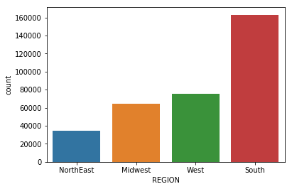

```python
ax = sb.countplot(x="REGION", data=t)
plt.xticks(ticks=[0,1,2,3],labels=list(regionIndex.keys()));
```

Let's have some fun and plot these as we do have data on latitude and longitude!

```python
import csv, json
from geojson import Feature, FeatureCollection, Point
import geopandas as gpd

def populate_geojson(dataframe):
    features = []
    dataframe.apply(lambda x: (
                    features.append(
            Feature(
                geometry = Point((x['LONGITUD'], x['LATITUDE'])),
                properties = {
                    'region': x['REGION']
                }
            )
        )
        # neater plotting for non-composite geoprojections
        if (x['LONGITUD'] < 0.0 and x['LONGITUD'] > -125.0) else None
        )
                    ,axis=1)
    collection = FeatureCollection(features)

    with open("GeoObs.geojson", "w") as f:
        f.write('%s' % collection)
```

```python
geodata = gpd.read_file('GeoObs.geojson')
us_geodata = gpd.read_file('gz_2010_us_040_00_500k.json')
us_geodata = us_geodata.drop([16,19,29]); # REMOVE ALASKA, HI AND PR FOR NEATER PLOTTING
```

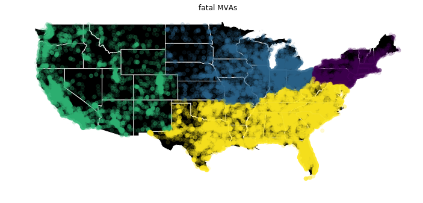

```python
f, ax = plt.subplots(1, figsize=(12, 12))
us_geodata.plot(ax = ax, facecolor='black', edgecolor='white');
geodata.plot(ax=ax,column='region',alpha=0.1);
plt.axis("off");
plt.title('fatal MVAs');
```

Our classes are imbalanced. This does not mean that people are more likely to end up in a fatal MVA in the South as these values are not normalized by the number of drivers/population. However it is important to note that our data has imbalanced classes. This could also be a useful insight to our client as the load of processing claims may be an important variable in their decision.

```python
drivercount = {
        "NorthEast": 3.860299e+07,
        "Midwest" : 4.747247e+07,
        "West" : 5.484473e+07,
        "South" : 8.663820e+07
}
```

```python
t['REGION'].value_counts(sort=False).divide(list(drivercount.values()))*1e+06
```

```
0     897.495246
1    1355.754188
2    1377.889908
3    1881.190976
dtype: float64
```

We see that the density values (number of fatal MVAs per million drivers are on the same order of magnitude now and are comparable.

Now, let's check how our other classes look like.

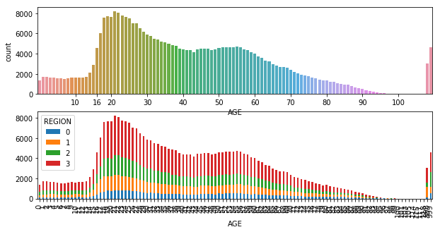

```python
fig, ((ax1, ax2)) = plt.subplots(2,1,figsize=(10,5))
plt.subplot(2,1,1)
sb.countplot(x="AGE",data=t)
plt.xticks(ticks = [10,16,20,30,40,50,60,70,80,90,100],labels = [10,16,20,30,40,50,60,70,80,90,100]);
t[['REGION','AGE']].groupby(['AGE','REGION']).size().unstack().plot(ax=ax2,kind='bar', stacked=True,xticks = [10,16,20,30,40,50,60,70,80,90,100])
```

What are some other important columns?

```python
t.columns
```

```
Index(['ST_CASE', 'STATE', 'PEDS', 'PERSONS', 'RUR_URB', 'LATITUDE',
       'LONGITUD', 'FATALS', 'NOT_HOUR', 'NOT_MIN', 'HOSP_HR', 'HOSP_MN',
       'AGE', 'SEX', 'PER_TYP', 'INJ_SEV', 'REST_USE', 'REST_MIS', 'AIR_BAG',
       'DOA', 'DRUGS', 'REGION'],
      dtype='object')
```

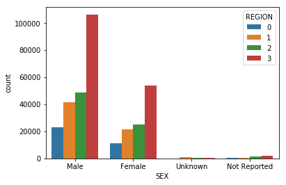

```python
ax = sb.countplot(x="SEX", hue='REGION', data=t)
plt.xticks(ticks = [0,1,2,3],labels = ["Male","Female","Unknown","Not Reported"]);
```

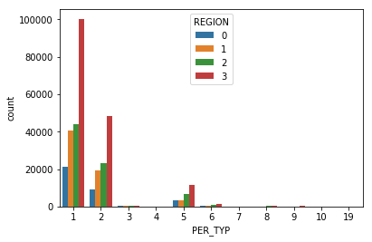

```python
ax = sb.countplot(x="PER_TYP", hue='REGION', data=t)
```

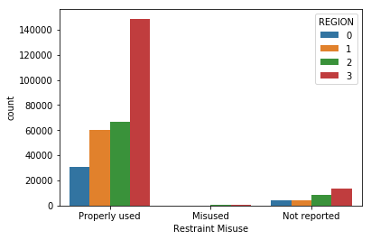

```python
ax = sb.countplot(x="REST_MIS", hue='REGION', data=t)
plt.xticks(ticks=[0,1,2],labels=['Properly used','Misused','Not reported'])
plt.xlabel("Restraint Misuse");
```

Interestingly enough, data about response time is included into our dataset but is in very bad condition. It is split in columns for t-hours and t-minutes and it contains many missing values so let's clean that up and convert it into one unit i.e. merge it into RESPONSE_TIME in minutes.

```python
def populate_response_time(data):
    response_time = data.apply(lambda x:
                                        calculate_response_time(
                                            x
                                        )

                               if time_valid(x) else time_valid_sub(x)
                                        ,
                                        axis=1)
    data['RESPONSE_TIME'] = response_time

def calculate_response_time(row):
    HOSP_HR, NOT_HOUR, HOSP_MIN, NOT_MIN = row[['HOSP_HR','NOT_HOUR','HOSP_MN','NOT_MIN']]

    if HOSP_HR < NOT_HOUR:
        hour_diff = HOSP_HR+23-NOT_HOUR # interval crossing midnight

    elif HOSP_HR == NOT_HOUR:
        hour_diff = 0
    else:
        hour_diff = HOSP_HR - NOT_HOUR -1

    if hour_diff >= 0:
        min_diff = HOSP_MIN + (60-NOT_MIN)
    else:
        min_diff = HOSP_MIN - NOT_MIN

    result = hour_diff*60+min_diff

    return result if result < 180 else 180


def time_valid(row):

    if row['HOSP_HR'] > 23 or row['NOT_HOUR'] > 23 or row['HOSP_MN'] > 59 or row['NOT_MIN'] > 59:
        return False
    return True

def time_valid_sub(row):
    if row['HOSP_HR'] < 23 or row['NOT_HOUR'] < 23:
        if row['HOSP_MN'] > 59 or row['NOT_MIN'] > 59:
            return -1  # instead of dropping these let's fill them in as -1 instead of NaN
        else:
            return (row['HOSP_HR'] - row['NOT_HOUR'])*60
        # when the minutes are missing we'll assume the full length of an hour, but will check
        # how this affects the distribution
    else:
        return -1 # instead of dropping these let's fill them in as -1 instead of NaN
```

```python
populate_response_time(t)
```

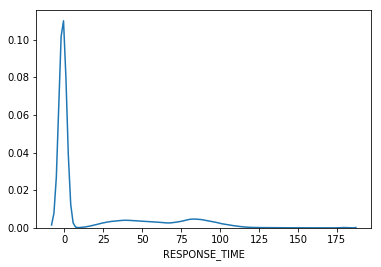

```python
sb.distplot(t['RESPONSE_TIME'], bins=50, kde=True,hist=False)
```

We see that we have many -1 i.e. NaN values so let's drop those for the sake of getting an idea of the distribution and see how the response times vary regionally.

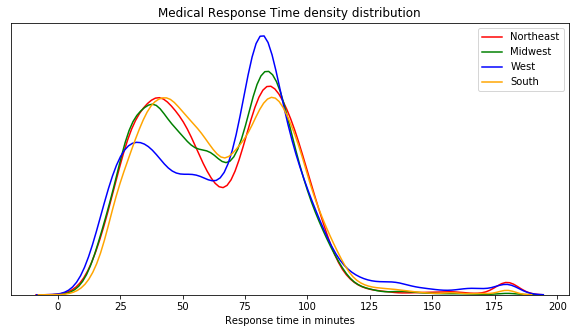

```python
def plotMRTbyregion(tt,region):
    t = tt[tt['REGION']==region]
    t = t[t['RESPONSE_TIME']>0]

    if region == 0:
        color = "red"
        name = "Northeast"
    if region == 1:
        color = "green"
        name = "Midwest"
    if region == 2:
        color = "blue"
        name= "West"
    if region == 3:
        color = "orange"
        name = "South"

    sb.distplot(t['RESPONSE_TIME'], bins=50, kde=True, color=color,hist=False,label=(name))
plt.figure(figsize=(10,5))
plotMRTbyregion(t,0)
plotMRTbyregion(t,1)
plotMRTbyregion(t,2)
plotMRTbyregion(t,3)
plt.xlabel('Response time in minutes')
plt.yticks([])
plt.title('Medical Response Time density distribution');
```

Additionally, all regions have balanced modes apart from the West whose latter peak is much more significant. This may be something to explore later!

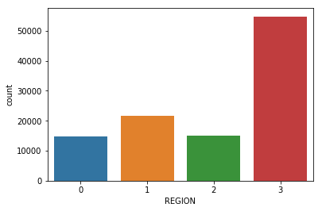

```python
tt = t[t['RESPONSE_TIME']>0]
ax = sb.countplot(x="REGION", data=tt)
```

```python
tt['REGION'].value_counts(sort=False).divide(list(drivercount.values()))*1e+06
```

```
0    380.618185
1    453.694531
2    275.286249
3    632.330773
dtype: float64
```

Lastly, let's finish cleaning up the columns, summarize our EDAs and points of further action and then move over to analyzing the data.

```python
def urbanrural_categorizer(table):
    column = table.apply(lambda data:
        'RURAL' if data['RUR_URB'] == 1
        else ('URBAN' if data['RUR_URB'] == 2 else 'RU-UNKNOWN')
    ,axis = 1)
    table['RUcat'] = column
```

```python
def isOccupant(table):
    column = table.apply(lambda x:
                         int(x['PER_TYP'] != 3)
                        ,axis = 1)
    table['OCCUPANT'] = column
```

```python
urbanrural_categorizer(t)
isOccupant(t)
```

```python
INJURY_SEVERITY_DICTIONARY ={
    0: "No Apparent Injury (O)",
    1: "Possible Injury (C)",
    2: "Suspected Minor Injury (B)",
    3: "Suspected Serious Injury (A)",
    4: "Fatal Injury (K)",
    5: "Injured, Severity Unknown",
    6: "Died Prior to Crash",
    9: "Unknown/Not Reported"
}
```

```python
def bin_injury(row):
    if row['INJ_SEV'] in [0,1,2,9]:
        return 'INJ_GRADE-1'
    if row['INJ_SEV'] in [3,5]:
        return 'INJ_GRADE-2'
    return 'INJ_GRADE-3'
t['INJ'] = t.apply(lambda x: bin_injury(x),axis=1)
```

```python
def bin_restraint(row):
    if row['REST_USE'] != 20:
        if row['REST_MIS'] == 1:
            return 'MISUSED'
        else:
            return 'PROPERLY-USED'
    else:
        return 'NOT-USED'

t['RESTRAINT'] = t.apply(lambda x: bin_restraint(x),axis=1)
```

```python
def bin_drugs(row):
    if row['DRUGS'] == 1:
        return 1
    else:
        return 0
t['DRUGS'] = t.apply(lambda x: bin_drugs(x),axis=1)
```

```python
def bin_doa(row):
    if row['DOA'] == 7:
        return 'DIED_AT_SCENE'
    if row['DOA'] == 8:
        return 'DIED_EN_ROUTE'
    else:
        return 'NOT_DOA'
t['DOA'] = t.apply(lambda x: bin_doa(x),axis=1)
```

```python
def bin_airbag(row):
    if row['AIR_BAG'] > 10:
        return 'NOT_DEPLOYED'
    else:
        return 'DEPLOYED'
t['AIR_BAG'] = t.apply(lambda x: bin_airbag(x),axis=1)
```

```python
tsub = t[['PERSONS','FATALS','AGE','SEX','DRUGS','AIR_BAG','DOA','REGION','RESPONSE_TIME','RUcat','OCCUPANT','INJ','RESTRAINT']]
```

```python
tsub = tsub.reset_index()
```

# Data Analysis

For our data analysis we will be using the following methods:

### 1. Frequent Pattern Mining (Association Rules)

### 2. K-means + K-modes clustering with cost measure being the regional separability

### 3. Decision Trees and Random Forests with target variable 'REGION''

For our frequent patter analysis we will categorize all data and so far only response time and age are continous variables. So let's categorize them.

```python
def categorize_response_time(table):
    # based on histograms it makes sense to categorize the data as
    # -2 -- 0 --- 25 --- 35 ---- 45 ----- 60 ---- 80 ---- 100 ------ 180(max)
    bins = [-2,0,25,35,45,70,181]
    categorical_RT = pd.cut(table['RESPONSE_TIME'],bins)
    table['CRT'] = categorical_RT
```

```python
def adjustage(table):
    bins = [0,16,25,35,50,70,250]
    categorical_RT = pd.cut(table['AGE'],bins)
    table['AGE_C'] = categorical_RT
```

```python
categorize_response_time(tsub)
adjustage(tsub)
```

```python
tsub = pd.DataFrame(tsub)
```

```python
tsub_CAT = tsub[['FATALS','AGE_C','SEX','DRUGS','AIR_BAG','DOA','REGION','CRT','RUcat','OCCUPANT','INJ','RESTRAINT']]
```

```python
tsub_CAT_binary = pd.get_dummies(tsub_CAT.astype(str))
```

```python
np.shape(tsub_CAT_binary)
```

```
(337560, 50)
```

```python
from mlxtend.frequent_patterns import apriori

frequent_itemsets=apriori(tsub_CAT_binary, min_support=0.2, use_colnames=True)
```

```python
from mlxtend.frequent_patterns import association_rules

rules_conf=association_rules(frequent_itemsets, metric="confidence", min_threshold=0.8)
```

```python
rules_conf.head(4)
```

|  | antecedents | consequents | antecedent support | consequent support | support | confidence | lift | leverage | conviction |
| --- | --- | --- | --- | --- | --- | --- | --- | --- | --- |
| 0 | (AGE_C_(50.0, 70.0]) | (FATALS_1) | 0.221978 | 0.884809 | 0.200723 | 0.904245 | 1.021967 | 0.004315 | 1.202983 |
| 1 | (SEX_1) | (FATALS_1) | 0.649956 | 0.884809 | 0.580581 | 0.893263 | 1.009555 | 0.005495 | 1.079207 |
| 2 | (SEX_2) | (FATALS_1) | 0.331837 | 0.884809 | 0.286601 | 0.863679 | 0.976120 | -0.007012 | 0.845001 |
| 3 | (FATALS_1) | (DRUGS_0) | 0.884809 | 0.949449 | 0.839409 | 0.948690 | 0.999201 | -0.000671 | 0.985212 |

```python
rules = rules_conf[rules_conf['antecedents'].astype(str).str.contains("REGION")]
```

```python
rules.sort_values(by='lift',ascending=False).head()
```

|  | antecedents | consequents | antecedent support | consequent support | support | confidence | lift | leverage | conviction |
| --- | --- | --- | --- | --- | --- | --- | --- | --- | --- |
| 3762 | (INJ_INJ_GRADE-1, OCCUPANT_1, REGION_3) | (DOA_NOT_DOA, DRUGS_0, RESTRAINT_PROPERLY-USED) | 0.222873 | 0.668654 | 0.207148 | 0.929446 | 1.390024 | 0.058123 | 4.696330 |
| 2703 | (INJ_INJ_GRADE-1, REGION_3) | (DOA_NOT_DOA, DRUGS_0, RESTRAINT_PROPERLY-USED) | 0.224274 | 0.668654 | 0.208197 | 0.928315 | 1.388333 | 0.058235 | 4.622231 |
| 3763 | (INJ_INJ_GRADE-1, REGION_3) | (DOA_NOT_DOA, OCCUPANT_1, DRUGS_0, RESTRAINT_P... | 0.224274 | 0.665654 | 0.207148 | 0.923639 | 1.387567 | 0.057859 | 4.378487 |
| 1952 | (INJ_INJ_GRADE-1, REGION_3) | (DOA_NOT_DOA, FATALS_1, DRUGS_0) | 0.224274 | 0.656956 | 0.202622 | 0.903455 | 1.375215 | 0.055284 | 3.553223 |
| 3330 | (INJ_INJ_GRADE-1, OCCUPANT_1, REGION_3) | (DOA_NOT_DOA, FATALS_1, DRUGS_0) | 0.222873 | 0.656956 | 0.201345 | 0.903407 | 1.375141 | 0.054927 | 3.551430 |

```python
np.shape(rules)
```

```
(535, 9)
```

```python
np.shape(rules[rules['antecedents'].astype(str).str.contains("REGION_3")])
```

```
(526, 9)
```

Let's now use clustering! We can do K-modes with our categorical data, but I like to use continous variables in any algorithms that support them so let's use a variation of K-means that uses both categorical and continous variables. However, remember that K-means uses a cost function that is a distance measure so lets make sure we scale our continuous variables properly!

```python
from sklearn.preprocessing import MinMaxScaler
tsub_k = tsub
tsub_k[['AGE','RESPONSE_TIME']] = pd.DataFrame(MinMaxScaler().fit_transform(t[['AGE','RESPONSE_TIME']].astype(float).values.reshape(-1,2)),columns=['AGE','RESPONSE_TIME'])
```

```python
tsub_k
```

|  | index | PERSONS | FATALS | AGE | SEX | DRUGS | AIR_BAG | DOA | REGION | RESPONSE_TIME | RUcat | OCCUPANT | INJ | RESTRAINT | CRT | AGE_C |
| --- | --- | --- | --- | --- | --- | --- | --- | --- | --- | --- | --- | --- | --- | --- | --- | --- |
| 0 | 0 | 1 | 1 | 0.055055 | 1 | 0 | NOT_DEPLOYED | DIED_AT_SCENE | 3 | 0.000000 | RURAL | 1 | INJ_GRADE-3 | NOT-USED | (-2, 0] | (50.0, 70.0] |
| 1 | 1 | 2 | 2 | 0.024024 | 1 | 0 | DEPLOYED | DIED_AT_SCENE | 3 | 0.000000 | URBAN | 1 | INJ_GRADE-3 | NOT-USED | (-2, 0] | (16.0, 25.0] |
| 2 | 2 | 2 | 2 | 0.024024 | 1 | 0 | DEPLOYED | DIED_AT_SCENE | 3 | 0.000000 | URBAN | 1 | INJ_GRADE-3 | PROPERLY-USED | (-2, 0] | (16.0, 25.0] |
| 3 | 3 | 2 | 1 | 0.037037 | 2 | 0 | DEPLOYED | DIED_AT_SCENE | 3 | 0.000000 | RURAL | 1 | INJ_GRADE-3 | NOT-USED | (-2, 0] | (35.0, 50.0] |
| 4 | 4 | 2 | 1 | 0.036036 | 1 | 0 | NOT_DEPLOYED | NOT_DOA | 3 | 0.000000 | RURAL | 1 | INJ_GRADE-1 | NOT-USED | (-2, 0] | (35.0, 50.0] |
| ... | ... | ... | ... | ... | ... | ... | ... | ... | ... | ... | ... | ... | ... | ... | ... | ... |
| 337555 | 81615 | 4 | 1 | 0.026026 | 1 | 1 | NOT_DEPLOYED | DIED_AT_SCENE | 2 | 0.370166 | RURAL | 1 | INJ_GRADE-3 | PROPERLY-USED | (45, 70] | (25.0, 35.0] |
| 337556 | 81616 | 4 | 1 | 0.027027 | 2 | 0 | DEPLOYED | NOT_DOA | 2 | 0.370166 | RURAL | 1 | INJ_GRADE-1 | PROPERLY-USED | (45, 70] | (25.0, 35.0] |
| 337557 | 81617 | 4 | 1 | 0.000000 | 1 | 0 | DEPLOYED | NOT_DOA | 2 | 0.370166 | RURAL | 1 | INJ_GRADE-2 | PROPERLY-USED | (45, 70] | NaN |
| 337558 | 81618 | 4 | 1 | 0.030030 | 1 | 0 | DEPLOYED | NOT_DOA | 2 | 0.370166 | RURAL | 1 | INJ_GRADE-1 | PROPERLY-USED | (45, 70] | (25.0, 35.0] |
| 337559 | 81619 | 1 | 1 | 0.028028 | 1 | 0 | DEPLOYED | NOT_DOA | 2 | 1.000000 | RURAL | 1 | INJ_GRADE-3 | PROPERLY-USED | (70, 181] | (25.0, 35.0] |

337560 rows × 16 columns

```python
tsub_CAT = tsub[['FATALS','SEX','DRUGS','AIR_BAG','DOA','REGION','RUcat','OCCUPANT','INJ','RESTRAINT']]
tsub_k_categorical = pd.concat(
    [pd.get_dummies(tsub_CAT.astype(str)),
    tsub_k[['AGE','RESPONSE_TIME']]],
    axis =1 )
```

```python
from sklearn.cluster import KMeans
np.random.seed(123)
tt_kmeans = KMeans(4).fit(tsub_k_categorical)
pd.DataFrame(tt_kmeans.cluster_centers_, columns = tsub_k_categorical.columns)  # look at centroids
```

|  | FATALS_1 | FATALS_10 | FATALS_13 | FATALS_2 | FATALS_20 | FATALS_3 | FATALS_4 | FATALS_5 | FATALS_6 | FATALS_8 | FATALS_9 | SEX_1 | SEX_2 | SEX_8 | SEX_9 | DRUGS_0 | DRUGS_1 | AIR_BAG_DEPLOYED | AIR_BAG_NOT_DEPLOYED | DOA_DIED_AT_SCENE | DOA_DIED_EN_ROUTE | DOA_NOT_DOA | REGION_0 | REGION_1 | REGION_2 | REGION_3 | RUcat_RU-UNKNOWN | RUcat_RURAL | RUcat_URBAN | … |
| --- | --- | --- | --- | --- | --- | --- | --- | --- | --- | --- | --- | --- | --- | --- | --- | --- | --- | --- | --- | --- | --- | --- | --- | --- | --- | --- | --- | --- | --- | --- |
| 0 | 0.879286 | 4.835122e-05 | 0.000029 | 0.092351 | 2.901073e-05 | 0.019012 | 0.005773 | 0.001383 | 0.001141 | 5.125230e-04 | 4.351610e-04 | 6.354511e-01 | 3.489411e-01 | 0.008171 | 7.436418e-03 | 0.964578 | 0.035422 | 0.506779 | 0.493221 | 1.465494e-14 | 4.375840e-15 | 1.000000e+00 | 0.084953 | 0.226303 | 0.199691 | 0.489053 | 0.001151 | 9.988492e-01 | -1.328493e-12 | … |
| 1 | 0.810112 | 1.192165e-04 | 0.000298 | 0.135966 | 2.384330e-04 | 0.034823 | 0.012136 | 0.004530 | 0.001335 | 3.576495e-04 | 8.345156e-05 | 7.203419e-01 | 2.787997e-01 | 0.000250 | 6.080042e-04 | 0.908716 | 0.091284 | 0.503320 | 0.496680 | 9.892705e-01 | 1.072949e-02 | -1.084022e-12 | 0.082522 | 0.194120 | 0.231447 | 0.491911 | 0.005377 | 5.581479e-01 | 4.364755e-01 | … |
| 2 | 0.924601 | -9.500322e-18 | 0.000333 | 0.060660 | -5.003593e-17 | 0.008844 | 0.003527 | 0.001474 | 0.000562 | 2.338082e-16 | 1.432231e-16 | 1.991740e-13 | 9.220039e-01 | 0.018881 | 5.911563e-02 | 0.976259 | 0.023741 | 0.393788 | 0.606212 | 1.448841e-14 | 2.825057e-03 | 9.971749e-01 | 0.121670 | 0.167959 | 0.238603 | 0.471767 | 0.013178 | -4.707346e-13 | 9.868222e-01 | … |
| 3 | 0.933790 | 2.638677e-17 | 0.000129 | 0.054085 | -8.409343e-17 | 0.008040 | 0.002519 | 0.001018 | 0.000418 | -2.569559e-16 | 2.068658e-16 | 9.998392e-01 | 9.886536e-14 | 0.000161 | 3.858025e-15 | 0.952926 | 0.047074 | 0.390120 | 0.609880 | 1.462719e-14 | 2.069062e-03 | 9.979309e-01 | 0.128700 | 0.161923 | 0.234865 | 0.474512 | 0.011460 | -5.793144e-13 | 9.885398e-01 | … |

Let's stop for a minute here. Sometimes putting everything down the drain and seeing what happens is a valid approach but right now we should stop and ask ourseleves how exactly are we going about this?

Why are we look at the centroids? What exactly are we looking for? We are indeed looking to cluster our data well, but the only meaningful result we can obtain is if we cluster them with boundaries that also cleave them regionally. We still care about the boundaries (we want them to be separable otherwise how can we say they are two separate clusters) but we care more that they are regionally homogeneous so that will be our number 1 metric -> measuring regional homogeneity.

Let's look at the mean sum of squares of our samples and see if there's a cluster range for which the elbow metric deems good.

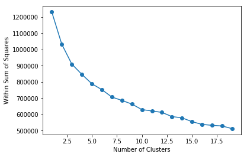

```python
wss = []
for i in np.arange(1, 20, 1):
    wss.append(KMeans(i).fit(tsub_k_categorical).inertia_)
plt.plot(np.arange(1, 20, 1), wss, 'o-')
plt.xlabel("Number of Clusters")
plt.ylabel("Within Sum of Squares")
plt.show()
```

The elbow metric doesn't identify any cluster number to be especially good, so lets narrow down our range do be 4 to 10 (as less than 4 is not that useful for us and larger for 10 will probably cleave them in a way that doesn't coincide with regions).

So for every number of clusters we will do the following:

1. perform K-means
2. (optional) produce a silhouette chart to see how separable the clusters are

   ```
        this might take a while as our dataset is relatively large for an algorithm like this
   ```

3. produce a homogeneity matrix:

   ```
        H(n_cluster) = n_cluster x 4-regions
        --> for every cluster measure the contribution of each region
            --> good regional homogeneity is 1 0 0 0 (one major region in a cluster)
            --> bad regional homogeneity is 0.25 0.25 0.25 0.25 (all regions equally present -> no conclusion)
   ```

```python
global normalization
normalization = tsub['REGION'].value_counts(sort=False).to_numpy() ## this is to account for class imbalance
```

```python
def homogeneity_matrix(cluster_labels, data,n):
    data['labels'] = cluster_labels
    matrix = (tsubc[['labels','REGION_0','REGION_1','REGION_2','REGION_3']].groupby('labels').sum().values)
    for cluster in range(0,n):
        for region in range (0,4):
            matrix[cluster,region] /= normalization[region]
        matrix[cluster,:] /= np.sum(matrix[cluster,:])
    plt.imshow(matrix,vmin=0, vmax=1, cmap='jet')
    plt.colorbar()
    plt.show()
```

```python
def silhouette_chart(sample_silhouette_values, n_clusters):
    y_lower = 10
    for i in range(n_clusters):
        ith_cluster_silhouette_values = sample_silhouette_values[cluster_labels == i]
        ith_cluster_silhouette_values.sort()
        size_cluster_i = ith_cluster_silhouette_values.shape[0]
        y_upper = y_lower + size_cluster_i
        color = cm.nipy_spectral(float(i) / n_clusters)
        plt.fill_betweenx(np.arange(y_lower, y_upper), 0, ith_cluster_silhouette_values,
                          facecolor=color, edgecolor=color, alpha=0.7)
        plt.text(-0.05, y_lower + 0.5 * size_cluster_i, str(i))
        y_lower = y_upper + 10
    plt.title("The silhouette plot for the various clusters.")
    plt.xlabel("The silhouette coefficient values")
    plt.ylabel("Cluster label")
    plt.axvline(x=silhouette_avg, color="red", linestyle="--")
    plt.show()
```

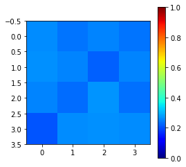

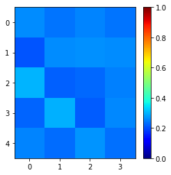

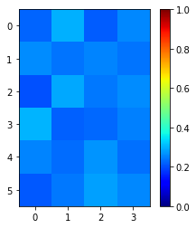

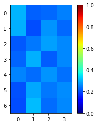

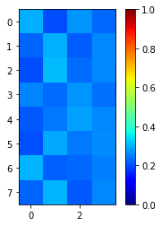

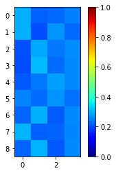

```python
from sklearn.metrics import silhouette_samples, silhouette_score

import matplotlib.cm as cm
tt =  tsub_k_categorical
for n_clusters in range(4,10):
    clusterer = KMeans(n_clusters=n_clusters)
    cluster_labels = clusterer.fit_predict(tt.drop(['REGION_0','REGION_1','REGION_2','REGION_3'], axis = 1))
   # silhouette_avg = silhouette_score(tt.drop(['REGION_0','REGION_1','REGION_2','REGION_3'], axis = 1)
   #                                   , cluster_labels)
   # print("For n_clusters =", n_clusters,
  #        "The average silhouette_score is :", silhouette_avg)
  #  sample_silhouette_values = silhouette_samples(tt.drop(['REGION_0','REGION_1','REGION_2','REGION_3'], axis = 1)
  #                                                , cluster_labels)
 #   silhouette_chart(sample_silhouette_values, n_clusters)
    homogeneity_matrix(cluster_labels,tt,n_clusters)
```

Now let's turn to supervised learning. Sometimes it is hard to reformulate our question that essentially is a question for unsupervised learning into something that a supervised learning algorithm can answer.

In this case we can choose a method that provides insight into how it's making its decision - decision trees (or random forests or any ensemble version). We can provide our target variable to be the region we are looking for and see whether main features that decrease the entropy (or any other split criterion) differ among the regions. We also need to look at how good our model is so that we can judge whether the comparison is valid and to do that we should penalize for both false positives as well as false negatives. Since our dataset will naturally be class imbalanced (as we're only looking at one region at a time) some kind of a trade-off between metrics is needed and what's better than looking at our F-score?

```python
from sklearn.model_selection import train_test_split
from sklearn.ensemble import RandomForestClassifier
from sklearn.tree import DecisionTreeClassifier
from sklearn.metrics import accuracy_score
from sklearn.metrics import f1_score
from sklearn.metrics import confusion_matrix
from sklearn.tree import export_text
```

Remember to use the fully categorical data frame (otherwise the splits will take a long time as each sample will be considered a class for our continous vars)!!

```python
for region in ['REGION_0','REGION_1','REGION_2','REGION_3']:
    print("Currently analyzing: ",region)
    print("- - - - - - - - - - - - - - - - - - ")
    X = tsub_CAT_binary.drop(['REGION_0','REGION_1','REGION_2','REGION_3','CRT_(-2, 0]'],axis=1)
    Y = tsub_CAT_binary[region]
    X_train, X_test, Y_train, Y_test = train_test_split(X, Y, test_size = 0.2)
    dts = DecisionTreeClassifier(criterion = "entropy")
    dts.fit(X_train, Y_train)
    influence = pd.Series(dts.feature_importances_, index = X.columns)
    influence.sort_values(inplace = True, ascending = False)
    print(influence[0:4])
    dt_pred = dts.predict(X_test)
    print('Score: ' , f1_score(dt_pred, Y_test))
    print("\n")

    print(pd.crosstab(dt_pred, Y_test, rownames = ["Predicted"], colnames = ["Actual"]))
    print("\n")
    print("TREE ::- - - - - - - - - - - - - - - - - - ")

    text_tree = export_text(dts, feature_names = list(X.columns),max_depth=1)
    print(text_tree)
```

```
Currently analyzing:  REGION_0
- - - - - - - - - - - - - - - - - -
RUcat_URBAN      0.081293
CRT_(70, 181]    0.043734
FATALS_1         0.040754
SEX_2            0.040341
dtype: float64
Score:  0.03054932735426009


Actual         0     1
Predicted
0          60485  6736
1            182   109


TREE ::- - - - - - - - - - - - - - - - - -
|--- RUcat_URBAN <= 0.50
|   |--- CRT_(70, 181] <= 0.50
|   |   |--- truncated branch of depth 30
|   |--- CRT_(70, 181] >  0.50
|   |   |--- truncated branch of depth 18
|--- RUcat_URBAN >  0.50
|   |--- CRT_(70, 181] <= 0.50
|   |   |--- truncated branch of depth 27
|   |--- CRT_(70, 181] >  0.50
|   |   |--- truncated branch of depth 22

Currently analyzing:  REGION_1
- - - - - - - - - - - - - - - - - -
RUcat_RURAL    0.110693
SEX_8          0.050622
SEX_2          0.046450
SEX_1          0.046133
dtype: float64
Score:  0.041058326539687245


Actual         0      1
Predicted
```

[output cut: 56 more lines]

```
0          25512  21362
1           9402  11236


TREE ::- - - - - - - - - - - - - - - - - -
|--- RUcat_RU-UNKNOWN <= 0.50
|   |--- CRT_(45, 70] <= 0.50
|   |   |--- truncated branch of depth 31
|   |--- CRT_(45, 70] >  0.50
|   |   |--- truncated branch of depth 23
|--- RUcat_RU-UNKNOWN >  0.50
|   |--- CRT_(70, 181] <= 0.50
|   |   |--- truncated branch of depth 21
|   |--- CRT_(70, 181] >  0.50
|   |   |--- truncated branch of depth 13
```

The importance of splits is around 0.03 and when it is higher then it carries less meaning (region 2 gives no meaning whatsover) so here we can conclude that if you have a fatality it is extremely hard to say what region it is in. Additionally the f1 score is EXTREMELY LOW except for region 3 where it only increases due to class imbalance. All these metrics tell us that there really is no regional cleavage among fatal MVAs. Running a RF model here won't make any difference as the range of importances and f-scores is extremely unlikely to be due to DT instability.

# CONCLUSION for the insurance company

We then proceeded to extract and infer data based on attributes given in the raw dataset. We were able to extract the medical response time [MRT] (the time needed to arrive at the hospital after the crash) and to see if that differed regionally and if so, is there more data to explain the difference and/or to account for possible increased risk of fatality? We assumed this would be useful information to you as you could estimate the financial risk of having regionally poorer transportation that could result in regionally higher death claims.